# Introdução à Análise Gráfica com R base

Janio Lima

08 novembro, 2022

# 1 Introdução

A análise gráfica (ou visual) é uma técnica fundamental para diversas etapas do processo de análise de dados. Na análise exploratória, sua importância é relacionada ao entedimento do conjunto de dados com o qual se trabalha. Na construção de modelos, a visualização é importante tanto para validar intuições sobre a validação de modelos quanto para análise dos resultados finais.

Há diversas ferramentas para análise gráfica, desde planilhas eletrônicas tracionais, ferramentas de Business Intelligence (BI) e linguagens de programção. Na linguagem R, há duas principais abordagens para esta análise: (1) **R base**: funções nativas de construção de gráficos; (2) **Tidyverse**: usando funções do pacote `ggplot2`.

Ambas alternativas possuem vantagens e desvantagens. Por exemplo, as funções nativas apresentam uma sintaxe mais simples e rodam em qualquer ambiente onde o R estiver instalado. O pacote ggplot2, apesar de ter uma sintaxe um pouco mais complexa, permite a construção de gráficos mais avançados e é muito bem integrado com outros pacotes do *universo* `tidyverse`.

Para exemplificar, construiremos um gráfico simples sobre o conjunto de dados de consumo de combustíveis de carros “mtcars” usando as funções básicas do R e sua versão equivalente no ggplot2. O conjunto de dados `mtcars` é um conjunto pequeno, com informações sobre 32 modelos de carros, com uma variável relativa ao desempenho de milhas por galão de combustível, que pode ser analisada como alvo. Há também 10 atributos dos veículos que podem ser analisadas como variáveis explicativas do consumo. Para analisar os detalhes do dataset pode ser usada a instrução `?mtcars` no console do R.

A Tabela “Dataset mtcars” exibe as primeiras observações do conjunto de dados em análise. O primeiro código a seguir cria uma visualização simples da dispersão entre o tamanho do motor (disp) e o consumo de combustível em milhas por galão (mpg). Na sequência é demonstrada a criação da mesma visualização usando o pacote `ggplot2`.

Dataset mtcars: primeiras observações

|  | mpg | cyl | disp | hp | drat | wt | qsec | vs | am | gear | carb |
| --- | --- | --- | --- | --- | --- | --- | --- | --- | --- | --- | --- |
| Mazda RX4 | 21.0 | 6 | 160 | 110 | 3.90 | 2.620 | 16.46 | 0 | 1 | 4 | 4 |
| Mazda RX4 Wag | 21.0 | 6 | 160 | 110 | 3.90 | 2.875 | 17.02 | 0 | 1 | 4 | 4 |
| Datsun 710 | 22.8 | 4 | 108 | 93 | 3.85 | 2.320 | 18.61 | 1 | 1 | 4 | 1 |
| Hornet 4 Drive | 21.4 | 6 | 258 | 110 | 3.08 | 3.215 | 19.44 | 1 | 0 | 3 | 1 |
| Hornet Sportabout | 18.7 | 8 | 360 | 175 | 3.15 | 3.440 | 17.02 | 0 | 0 | 3 | 2 |
| Valiant | 18.1 | 6 | 225 | 105 | 2.76 | 3.460 | 20.22 | 1 | 0 | 3 | 1 |

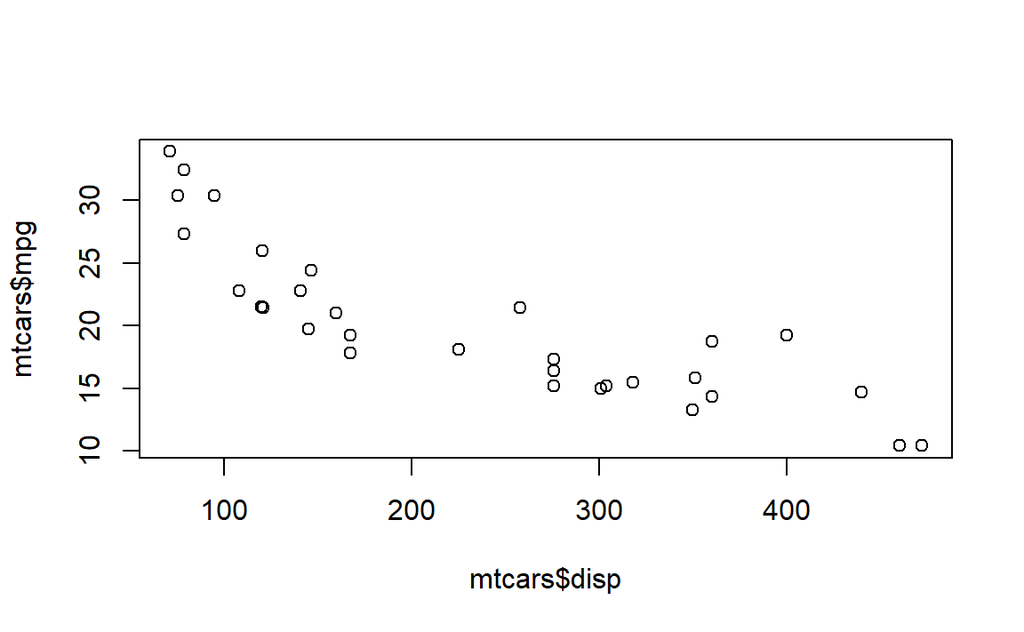

```r
#Gráfico de dispersão usando R base
plot(x = mtcars$disp, y = mtcars$mpg)
```

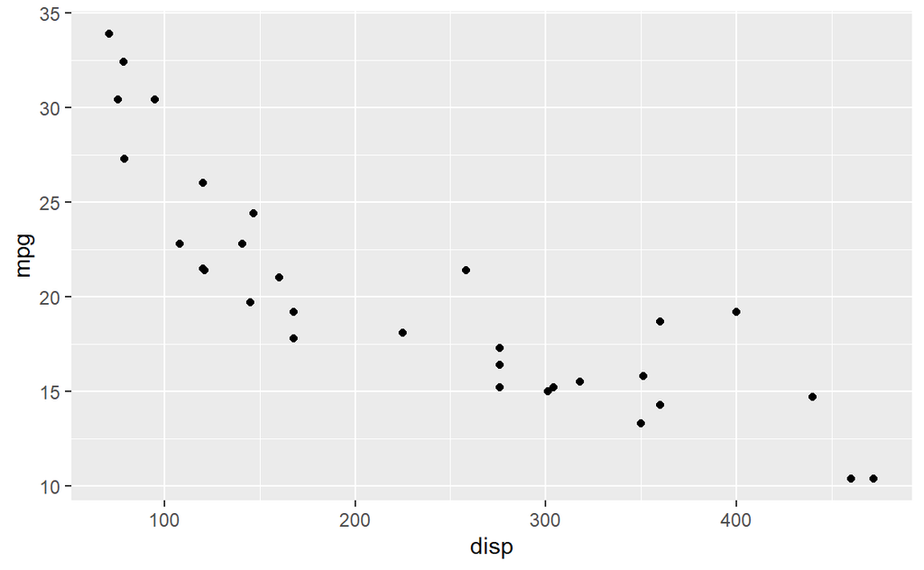

```r
#Gráfico de dispersão usando ggplot2
library(ggplot2)
ggplot(data = mtcars) +
  geom_point(mapping = aes(x = disp, y = mpg))
```

O gráfico apresentado é bem simples e, em ambos exemplos, foi usada a forma mais básica de construção. Isto é, não foram realizadas quaisquer configurações adicionais na visualização além da indicação da origem de dados e o tipo de gráfico. Percebe-se que ambos os gráficos, apesar de terem detalhes visuais diferentes, transmitem a mesma informação acerca da mudança de consumo à medida que o tamanho do motor é menor ou maior. Também é possível notar que a primeira opção usa um pouco menos de código, contudo o resultado do `ggplot2` é um pouco mais atrativo mesmo na configuração mais básica.

# 2 Tipos básicos de gráficos

```r
library(tidyverse, warn.conflicts = FALSE, verbose = FALSE, quietly = TRUE)
arquivo <- "https://raw.githubusercontent.com/janiosl/python.ds/master/data/yahoo_stock_12-12-2020.csv"
stocks <- read_csv(arquivo)
```

Na comparação entre gráficos criados com R base e `ggplot2`, já foi vista a função `plot`, uma das mais comuns para construção de gráficos. No exemplo anterior a função foi usada para criar um gráfico de dispersão, porém com pequenos ajustes podemos criar gráficos diferentes. Por exemplo, se o analista fornecer apenas um argumento de dados, ao invés da dispersão são exibidos os dados ao longo do tempo. O mesmo ocorre se o primeiro argumento for um campo data.

Na sequência de códigos abaixo temos três formas diferentes de exibir os mesmos dados. Inicialmente, será chamada a função `plot` passando apenas uma variável com o preço de fechamentos de uma ação. Como resultado é gerado um gráfico com os preços no eixo $y$ e a sequência ordenada em que aparecem no dataset no eixo $x$.

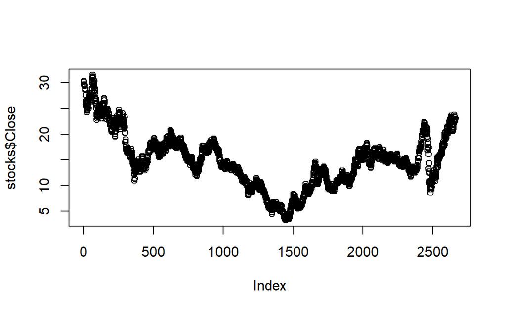

```r
plot(stocks$Close
     )
```

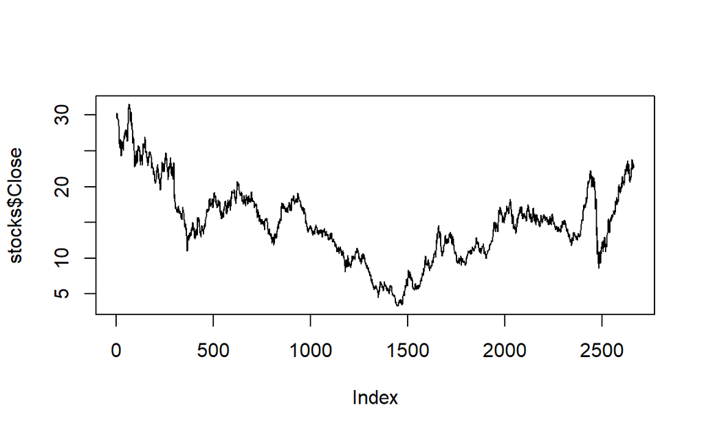

```r
plot(stocks$Close,
     type = "l"
     )
```

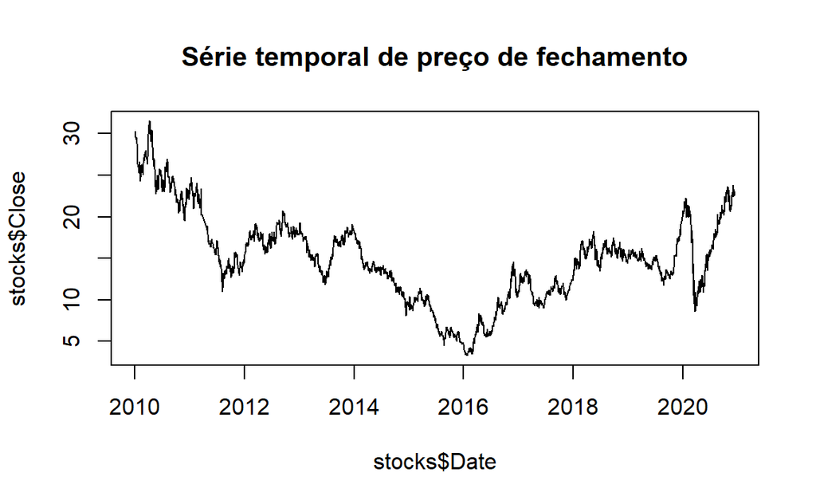

```r
plot(stocks$Date, stocks$Close,
     type = "l",
     main = "Série temporal de preço de fechamento"
     )
```

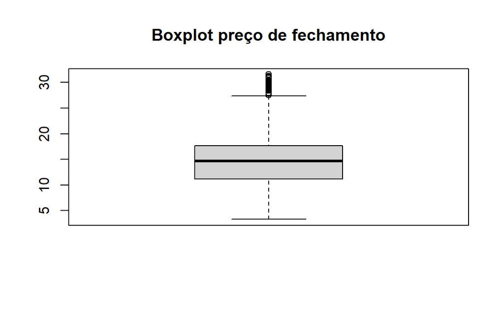

```r
boxplot(stocks$Close,
        main = "Boxplot preço de fechamento")
```

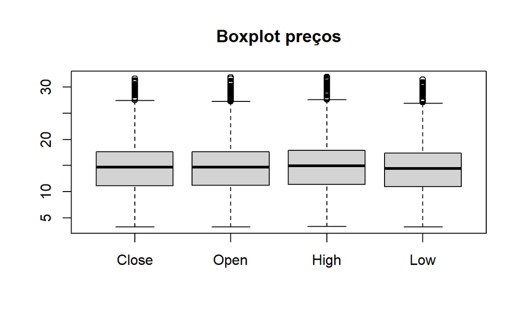

```r
boxplot(stocks$Close,
        stocks$Open,
        stocks$High,
        stocks$Low,
        names = c("Close", "Open", "High", "Low"),
        main = "Boxplot preços")
```

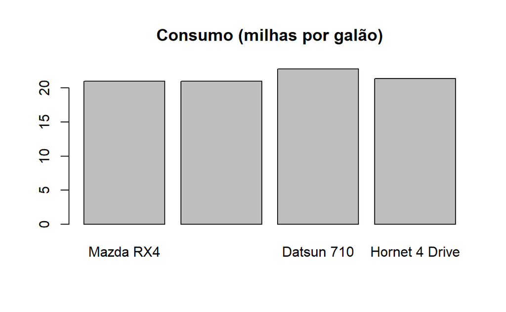

```r
barplot(mtcars[1:4,]$mpg,
        width = 0.7,
        names = row.names(mtcars[1:4,]),
        main = "Consumo (milhas por galão)"
        )
```

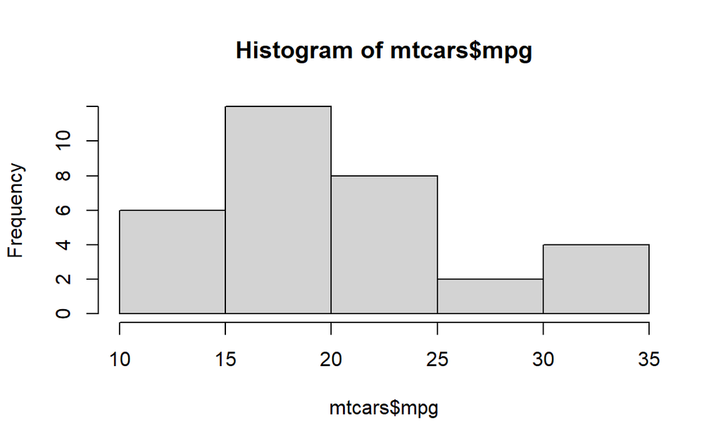

```r
hist(mtcars$mpg)
```

# 3 Personalização de elementos complementares

# 4 Gráficos compostos e painéis

# 5 Considerações Finais

# 6 Referências